# Projektarbeit Stefan Flachsbarth & Martin Haug Teil 9

Analyse von Wahlergebnissen, Strukturdaten und Presseberichterstattung Bundestagswahlen im Zeitraum 1990 - 2017

Stefan Flachsbarth, Martin Haug

2019-10-22

# 1 13. Textmining mit Elasticsearch

## 1.1 13.1. Vorbereitung

### 1.1.1 Installation der benötigten R-Pakete

```r
install.packages(c("dplyr", "kableExtra", "elastic", "elasticsearchr"))
```

### 1.1.2 Laden der Bibliotheken

```r
library(DBI)
library(dplyr)
library(elastic)
library(elasticsearchr)
library(ggplot2)
library(kableExtra)
library(plyr)
library(readr)
library(stopwords)
library(tidyverse)
library(tidytext)
```

### 1.1.3 Auslesen der Daten

```r
KillDbConnections <- function () {
  all_cons <- dbListConnections(RPostgreSQL::PostgreSQL())
  for(x in all_cons) +  dbDisconnect(x)
}

ReadPresseTablebyYear <- function(table_name, year) {
  # Initierung der Datenbank
  con <- dbConnect(RPostgreSQL::PostgreSQL(),
    host = 'hdm-sql.think-data.de',
    dbname = 'postgres',
    user = 'postgres',
    password = '%%CENSORED%%'
    # Der richtige Weg, um auf sichere Weise das Passwort abzufragen
    #password = rstudioapi::askForPassword("Database password")
    )

  # Konstruktion der Query
  query <- paste("SELECT * FROM ", table_name, " WHERE filename LIKE '%", year, "%'",sep="")

  # Ausführen der Query und Zurückgeben des Ergebnisses
  return(dbGetQuery(con, query))

  # Verbindungsabbau
  KillDbConnections()
}

ReadPresseTable <- function(table_name) {
  # Initierung der Datenbank
  con <- dbConnect(RPostgreSQL::PostgreSQL(),
    host = 'hdm-sql.think-data.de',
    dbname = 'postgres',
    user = 'postgres',
    password = '%%CENSORED%%'
    # Der richtige Weg, um auf sichere Weise das Passwort abzufragen
    #password = rstudioapi::askForPassword("Database password")
    )

  # Auslesen der Tabelle und Zurückgeben des Ergebnisses
  return(dbReadTable(con, table_name))

  # Verbindungsabbau
  KillDbConnections()
}

# Daten über die Funktion einlesen
presse1990 <- ReadPresseTablebyYear("presse", 1990)
presse1994 <- ReadPresseTablebyYear("presse", 1994)
presse1998 <- ReadPresseTablebyYear("presse", 1998)
presse2002 <- ReadPresseTablebyYear("presse", 2002)
presse2005 <- ReadPresseTablebyYear("presse", 2005)
presse2009 <- ReadPresseTablebyYear("presse", 2009)
presse2013 <- ReadPresseTablebyYear("presse", 2013)
presse2017 <- ReadPresseTablebyYear("presse", 2017)
```

### 1.1.4 Validierung der Daten aus der Datenbank

```r
kable(head(presse1990,1), caption = "Presseartikel 1990") %>%
  kable_styling(bootstrap_options = c("striped", "hover", "condensed", "responsive"), full_width = F) %>%
  scroll_box(width = "100%", height = "200px")
```

Presseartikel 1990

| row.names | id | header | text | publisher | author | link | filename | year | path |
| --- | --- | --- | --- | --- | --- | --- | --- | --- | --- |
| 1 | 1 | Die Berliner waehlen in Lindgruen und Rosa Zweitstimme ist die wichtige Stimme: Sie entscheidet ueber die tatsaechliche Prozentzahl und ueber die Zahl der Sitze im Parlament/ Erststimme bestimmt den D… | TAZ-Bericht Berlin. Ob das eine versteckte Koalitionsaussage ist? Zufall oder nicht, die BerlinerInnen duerfen bei den Wahlen zum Gesamtberliner Abgeordnetenhaus ausgerechnet rosafarbene und lindgruen… | TAZ-BERLIN Nr. 3275 vom 01.12.1990 Seite 37 | kd | https://www.wiso-net.de/document/TAZH__T901201.203 | Presse_1990_01_Html.htm | 1990 | Pressetexte/Presseartikel 1990 |

```r
kable(head(presse1994,1), caption = "Presseartikel 1994") %>%
  kable_styling(bootstrap_options = c("striped", "hover", "condensed", "responsive"), full_width = F) %>%
  scroll_box(width = "100%", height = "200px")
```

Presseartikel 1994

| row.names | id | header | text | publisher | author | link | filename | year | path |
| --- | --- | --- | --- | --- | --- | --- | --- | --- | --- |
| 27 | 2 | Radio Bremen befragt das Volk zur Bundestagswahl: *UEBERSCHRIFT: “Wahlspots sind Volksbelaestigung!” | TAZ-Bericht Bremen (taz) - Ein launiges Bonmot macht derzeit die Runde: Das felsdumme Steinzeitwerbefilmchen der CDU ist die einzige Chance, dass uns eine weitere Amtszeit des sitzfesten Kanzlers ersp… | TAZ, 13.10.1994, S. 20 / Die Wahrheit | harald keller | https://www.wiso-net.de/document/TAZ__T941013.140 | Presse_1994_01_Html.htm | 1994 | Pressetexte/Presseartikel 1994 |

```r
kable(head(presse1998,1), caption = "Presseartikel 1998") %>%
  kable_styling(bootstrap_options = c("striped", "hover", "condensed", "responsive"), full_width = F) %>%
  scroll_box(width = "100%", height = "200px")
```

Presseartikel 1998

| row.names | id | header | text | publisher | author | link | filename | year | path |
| --- | --- | --- | --- | --- | --- | --- | --- | --- | --- |
| 78 | 4 | Die Direktkandidaten und andere Wahlheiten Die Erststimme bei der Bundestagswahl ist für den Direktkandidaten. Eine Chance haben nur die der großen Parteien. Für wen soll, darf, kann man stimmen? Wo l… | TAZ-Bericht Wählt die Direktkandidaten der SPD, wenn ihr einen rot-grünen Wechsel wollt, forderte der grüne Parteichef Jürgen Trittin die Gefolgschaft seiner Partei diese Woche auf. “Aber Jürgen!”, mö… | TAZ-HAMBURG, 26.09.1998, S. 31 / Hamburger Thema | Silke Mertins | https://www.wiso-net.de/document/TAZ__T980926.296 | Presse_1998_01_Html.htm | 1998 | Pressetexte/Presseartikel 1998 |

```r
kable(head(presse2002,1), caption = "Presseartikel 2002") %>%
  kable_styling(bootstrap_options = c("striped", "hover", "condensed", "responsive"), full_width = F) %>%
  scroll_box(width = "100%", height = "200px")
```

Presseartikel 2002

id

header

text

publisher

author

link

filename

year

path

483

12

ZUR PERSON Zu einer Analyse der Bundestagswahl am

ZUR PERSON Zu einer Analyse der Bundestagswahl am Tag danach haben die TV-Moderatoren Günther Jauch und Harald Schmidt ihre Teilnahme an der SAT.1-Sendung “Talk im Turm” zugesagt. Beide stünden dafür, auf originelle Weise auszudrücken, was die Menschen im Land denken, sagte der Gastgeber der Sendung, Erich Böhme, in Berlin. Böhme, der seine Tätigkeiten als Talkmaster nach der Sendung vom 23. September beendet, kündigte zudem an, noch bis zur Wahl vier weitere Montags-Spezialausgaben des “Talk im Turm” zu moderieren. Termine der Live-Sendung sind der 26. August sowie der 2., 9. und 16. September. Böhme hatte die wöchentliche Gesprächsrunde 1990 als “Talk im Turm” begonnen. Seit Anfang 2000 läuft die Sendung als “Talk in Berlin” auf n-tv. Böhmes Nachfolger dort wird der ehemalige ZDF-Chefredakteur Klaus Bresser. Alexander Stock, Leiter der ZDF-Programmplanung, soll neuer Kommunikationschef des Mainzer Senders werden. Der 40-Jährige folgt Philipp Baum, der nun beim Pharmakonzern Boehringer Ingelheim die Kommunikation verantwortet.

Uwe Kockisch wird der Nachfolger von Joachim Król als “Commissario Brunetti” in der ARD. Der 58-jährige Berliner werde ab Folge fünf der Donna-Leon-Krimireihe einsteigen, hieß es von der ARD. Król wird sich nach den Filmen drei und vier, die am 10. und 17. Oktober in der ARD ausgestrahlt werden, verabschieden. Er will sich verstärkt um Kino-Produktionen kümmern. Kockisch spielte 22 Jahre lang am Maxim-Gorki-Theater in Berlin, für SAT.1 wirkte er im TV-Mehrteiler “Der Tunnel” und zuletzt in “Unsere Kinder - Verschollen im Urlaub” mit. Die Grünen-Politikerin Andrea Fischer wird Nachfolgerin von Erich Böhme beim n-tv-Talk “Im Grünen Salon”. Ein Sprecher des Berliner Fernsehsenders bestätigte eine entsprechende Vorabmeldung des “Tagesspiegel”. Der Zeitung zufolge soll die 42-jährige ehemalige Gesundheitsministerin die Talksendung zusammen mit Heinz Eggert moderieren, der seit dem Sendestart 1997 gemeinsam mit Böhme Gastgeber ist. Das Prinzip der Gesprächsrunde, die aus der Berliner Volksbühne übertragen wird, solle beibehalten werden.

Bonner General-Anzeiger, 19.08.2002, S. 30 Bonner Stadtausgabe General-Anzeiger / MEDIEN

https://www.wiso-net.de/document/GAZ__01B393B2563A6C1CC77A72E5C71EE505A5

Presse_2002_04_Html.htm

2002

Pressetexte/Presseartikel 2002

```r
kable(head(presse2005,1), caption = "Presseartikel 2005") %>%
  kable_styling(bootstrap_options = c("striped", "hover", "condensed", "responsive"), full_width = F) %>%
  scroll_box(width = "100%", height = "200px")
```

Presseartikel 2005

| row.names | id | header | text | publisher | author | link | filename | year | path |
| --- | --- | --- | --- | --- | --- | --- | --- | --- | --- |
| 651 | 16 | Briefwahl mit Rekord - Bundestagswahl: Direktkandidat und Partei ( zwei Stimmen sind… | Briefwahl mit Rekord Bundestagswahl: Direktkandidat und Partei ( zwei Stimmen sind am Sonntag möglich Am Sonntag wählen Weimar und das Weimarer Land ihre Vertreter für den Bundestag. Rund 125000 Wahlb… | Thüringer Allgemeine vom 16.09.05 Seite TAWE116 / Lokales Weimar Lokales Weimar | character(0) | https://www.wiso-net.de/document/TA__20050916-TAWE116-AUF | Presse_2005_02_Html.htm | 2005 | Pressetexte/Presseartikel 2005 |

```r
kable(head(presse2009,1), caption = "Presseartikel 2009") %>%
  kable_styling(bootstrap_options = c("striped", "hover", "condensed", "responsive"), full_width = F) %>%
  scroll_box(width = "100%", height = "200px")
```

Presseartikel 2009

id

header

text

publisher

author

link

filename

year

path

1691

37

Machterhalt mit “geklauter Mehrheit”?

Noch 6 Tage bis zur Bundestagswahl 2009 BERLIN

Sie will die Macht - mit allen Mitteln. Bundeskanzlerin Angela Merkel setzt zwar weiterhin auf eine klare Mehrheit für Schwarz-Gelb, doch angesichts des schrumpfenden Vorsprungs will sie auch auf Umwegen Kanzlerin bleiben. Mithilfe der sogenannten Überhangmandate. Und davon, das haben mehrere Wahl- und Parteiforscher hochgerechnet, könnte es bei der Bundestagswahl am Sonntag so viele wie noch nie geben. Sie könnten darüber entscheiden, wer künftig die Regierung stellt.

Was ist ein Überhangmandat?

Schickt eine Partei in einem Bundesland mehr Direktkandidaten per Erststimme in den Bundestag, als ihr per Zweitstimme anteilsmäßig zustünden, erhält sie diese Mandate zusätzlich. Das kam bereits zwölf Mal vor.

Wie viele gab es 2005?

16. Die SPD errang so neun zusätzliche Sitze, die CDU sieben.

Waren Überhangmandate schon mal entscheidend bei der Regierungsbildung?

Ja. Als sich Gerhard Schröder 2002 gegen Edmund Stoiber durchsetzte, verdankte er seine stabile Mehrheit den vier SPD-Überhangmandaten. Ohne sie hätte er nur eine Stimme Mehrheit gehabt. 1994 war es ähnlich. Da konnte die schwarz-gelbe Regierung Helmut Kohls dank der Überhangmandate ihre knappe Mehrheit von zwei auf zehn Mandate ausbauen

Was passiert, wenn ein Überhangmandatsträger ausfällt?

Anders als “normale” Abgeordnete werden die Inhaber eines Überhangmandats nicht ersetzt.

Wie sieht es bei dieser Wahl aus?

Experten sagen der Union besonders viele Überhangmandate voraus - bis zu 30 Stück. Durch das Erstarken der Linkspartei im Westen ist es zunehmend wahrscheinlicher, dass Unions-Direktkandidaten ihre Wahlkreise gewinnen.

Was sagt das Bundesverfassungsgericht zu der Reglung?

Im Juli 2008 hat es die Klausel im Wahlrecht, die dazu führen kann, dass eine Partei durch Überhangmandate trotz Stimmverlusts einen zusätzlichen Sitz erhält, als grundgesetzwidrig eingestuft. Allerdings hat das Parlament bis Juni 2011 Zeit, das Wahlrecht zu ändern.

Das ficht die Kanzlerin nicht an: Das Überhangmandat sei kein Mandat zweiter Klasse. Da gibt es auch andere Meinungen: “Verfassungwidrig, illegetim” sei es, wenn Merkel auf diese Weise eine stabile Mehrheit bekäme, schimpft Thomas Oppermann von der SPD. Volker Beck von den Grünen wird noch giftiger: Es sei “unanständig”, wenn Schwarz-Gelb darauf spekuliere, “mit einer geklauten Mehrheit zu regieren”.

BU:

Will auf alle Fälle weiterregieren: Angela Merkel

Hamburger Morgenpost vom 21.09.2009 Seite 4 / politik

(mk/ao)

https://www.wiso-net.de/document/MOPO__HMP2009092017498049

Presse_2009_05_Html.htm

2009

Pressetexte/Presseartikel 2009

```r
kable(head(presse2013,1), caption = "Presseartikel 2013") %>%
  kable_styling(bootstrap_options = c("striped", "hover", "condensed", "responsive"), full_width = F) %>%
  scroll_box(width = "100%", height = "200px")
```

Presseartikel 2013

| row.names | id | header | text | publisher | author | link | filename | year | path |
| --- | --- | --- | --- | --- | --- | --- | --- | --- | --- |
| 2496 | 54 | Vor der Bundestagswahl Im Falle eines Falles Von | Vor der Bundestagswahl Im Falle eines Falles Von Ulrich Lüke Die extreme Personalisierung dieser Bundestagswahl auf Angela Merkel und Peer Steinbrück hat zu einer fatalen Konsequenz geführt: Die meist… | Bonner General-Anzeiger, 19.09.2013, S. 2 / POL | character(0) | https://www.wiso-net.de/document/GAZ__201309192023640 | Presse_2013_02_Html(1).htm | 2013 | Pressetexte/Presseartikel 2013 |

```r
kable(head(presse2017,1), caption = "Presseartikel 2017") %>%
  kable_styling(bootstrap_options = c("striped", "hover", "condensed", "responsive"), full_width = F) %>%
  scroll_box(width = "100%", height = "200px")
```

Presseartikel 2017

| row.names | id | header | text | publisher | author | link | filename | year | path |
| --- | --- | --- | --- | --- | --- | --- | --- | --- | --- |
| 3753 | 81 | Die richtigen Bücher zur Bundestagswahl | 20 Tipps Bei der Bundestagswahl haben Sie zwei Stimmen, wir haben zwei Gattungen zu bieten: das Sachbuch und die schöne Literatur. Sämtliche aufgeführten Titel sind außerdem druckfrisch. Alles andere … | Welt online vom 23.09.2017 | character(0) | https://www.wiso-net.de/document/WEON__153327888 | Presse_2017_02_Html.htm | 2017 | Pressetexte/Presseartikel 2017 |

## 1.2 13.2. Transformation der Daten

### 1.2.1 Bereinigen der Publikationen

```r
# Funktion, um die Bereinigung der Publikationen durchzuführen
verlag_cleanup <- function(dataframe,column) {
  # Filter von Inhalten wie "$verlag vom 01.01.2001 ..."
  dataframe[[column]] <- gsub(" vom.*$", "", dataframe[[column]], ignore.case = TRUE)
  # Filter von Inhalten wie "$verlag print: Nr. 1 ..."
  dataframe[[column]] <- gsub(" print: nr. \\d.*$", "", dataframe[[column]], ignore.case = TRUE)
  # Filter von Inhalten wie "$verlag Nr. 1 ..."
  dataframe[[column]] <- gsub(" nr. \\d.*$", "", dataframe[[column]], ignore.case = TRUE)
  # Filter von Inhalten wie "$verlag, Jg. 52, 01.01.2001 ..."
  dataframe[[column]] <- gsub(", Jg. \\d.*$", "", dataframe[[column]], ignore.case = TRUE)
  # Filter von Inhalten wie "$verlag, 01.01.2001, S. 1 ..."
  dataframe[[column]] <- gsub(", \\d\\d.\\d\\d.\\d\\d\\d\\d.*$", "", dataframe[[column]], ignore.case = TRUE)
  # Filter von Inhalten wie "$verlag Nr. ..."
  dataframe[[column]] <- gsub("Nr. *$", "", dataframe[[column]], ignore.case = TRUE)

  # Vereinheitlichen der Groß- und Kleinschreibung
  # Entfernen aller Leerzeichen vor und nach der Publikation
  dataframe[[column]] <- tolower(dataframe[[column]]) %>% trimws()

  return(dataframe)
}

# Bereinigung über die neue Funktion durchführen
presse1990 <- verlag_cleanup(presse1990, "publisher")
presse1994 <- verlag_cleanup(presse1994, "publisher")
presse1998 <- verlag_cleanup(presse1998, "publisher")
presse2002 <- verlag_cleanup(presse2002, "publisher")
presse2005 <- verlag_cleanup(presse2005, "publisher")
presse2009 <- verlag_cleanup(presse2009, "publisher")
presse2013 <- verlag_cleanup(presse2013, "publisher")
presse2017 <- verlag_cleanup(presse2017, "publisher")
```

### 1.2.2 Enternen von Stopwörtern

#### 1.2.2.1 Generieren der Stopwort-Liste

```r
# list of German stopwords
stopword <- as_tibble(stopwords("de"))
stopword <- dplyr::rename(stopword, word=value)

# Erweiterte Liste mit deutschen Stopwörtern
stopword_extented <- read_tsv("https://raw.githubusercontent.com/solariz/german_stopwords/master/german_stopwords_full.txt", col_names = FALSE, comment = ";")
stopword_extented <- dplyr::rename(stopword_extented, word=X1)

# Liste der eigenen Stopwörtern
# bz ist ein Kürzel der badinschen zeitung
# mz ist ein Kürzel für mitteldeutsche zeitung
# rp ist ein Kürzel für rheinische post
# sz ist ein Kürzel für sächsische zeitung
# ta ist ein Kürzel der thüringer allgemeine
# taz ist ein Kürzel der tageszeitung
# tz ist ein Kürzel der tz - eine münchner zeitung
stopword_own <- tibble(word = c("bz", "mz", "rp", "sz", "tz", "ta", "taz"))

# Zusammenfügen und entfernen von Duplikaten
all_stopword <- bind_rows(stopword,stopword_extented, stopword_own) %>% distinct() %>% dplyr::rename(token = word)
```

#### 1.2.2.2 Anwenden der Stopwortlisten auf Artikeltext

```r
clean_stop_words_text <- function(df) {
  x_token <- df %>% unnest_tokens(token, text, token = "words", format = "text", to_lower = TRUE, drop = TRUE)
  x_token_count <- nrow(x_token)

  x_stop <- anti_join(x_token, all_stopword, by = 'token')
  x_stop_count <- nrow(x_stop)

  text <- ddply(x_stop, .(row.names), summarize, text=paste(token, collapse=" "))
  x_stop_joined <- join(x_stop, text, by="row.names") %>% select(-token) %>% ungroup()

  # Statistik f+r Artikeltext
  print(paste("Die Anzahl der Token in den Artikeltext wurden von", x_token_count, "auf", x_stop_count,"durch das Entfernen der Stopwörter reduziert."))

  return(x_stop_joined)
}

presse1990_stop <- clean_stop_words_text(presse1990)
```

```
[1] "Die Anzahl der Token in den Artikeltext wurden von 9085 auf 4366 durch das Entfernen der Stopwörter reduziert."
```

```r
presse1994_stop <- clean_stop_words_text(presse1994)
```

```
[1] "Die Anzahl der Token in den Artikeltext wurden von 25014 auf 12071 durch das Entfernen der Stopwörter reduziert."
```

```r
presse1998_stop <- clean_stop_words_text(presse1998)
```

```
[1] "Die Anzahl der Token in den Artikeltext wurden von 88562 auf 41285 durch das Entfernen der Stopwörter reduziert."
```

```r
presse2002_stop <- clean_stop_words_text(presse2002)
```

```
[1] "Die Anzahl der Token in den Artikeltext wurden von 103074 auf 48068 durch das Entfernen der Stopwörter reduziert."
```

```r
presse2005_stop <- clean_stop_words_text(presse2005)
```

```
[1] "Die Anzahl der Token in den Artikeltext wurden von 280359 auf 130651 durch das Entfernen der Stopwörter reduziert."
```

```r
presse2009_stop <- clean_stop_words_text(presse2009)
```

```
[1] "Die Anzahl der Token in den Artikeltext wurden von 240962 auf 111355 durch das Entfernen der Stopwörter reduziert."
```

```r
presse2013_stop <- clean_stop_words_text(presse2013)
```

```
[1] "Die Anzahl der Token in den Artikeltext wurden von 610440 auf 274218 durch das Entfernen der Stopwörter reduziert."
```

```r
presse2017_stop <- clean_stop_words_text(presse2017)
```

```
[1] "Die Anzahl der Token in den Artikeltext wurden von 1260980 auf 560084 durch das Entfernen der Stopwörter reduziert."
```

#### 1.2.2.3 Anwenden der Stopwortlisten auf Artikelüberschrift

```r
clean_stop_words_header <- function(df) {
  x_token <- df %>% unnest_tokens(token, header, token = "words", format = "text", to_lower = TRUE, drop = TRUE)
  x_token_count <- nrow(x_token)

  x_stop <- anti_join(x_token, all_stopword, by = 'token')
  x_stop_count <- nrow(x_stop)

  header <- ddply(x_stop, .(row.names), summarize, header=paste(token, collapse=" "))
  x_stop_joined <- join(x_stop, header, by="row.names") %>% select(-token) %>% ungroup()

  # Statistik f+r Artikeltext
  print(paste("Die Anzahl der Token in den Artikelüberschriften wurden von", x_token_count, "auf", x_stop_count,"durch das Entfernen der Stopwörter reduziert."))

  return(x_stop_joined)
}

presse1990_stop <- clean_stop_words_header(presse1990)
```

```
[1] "Die Anzahl der Token in den Artikelüberschriften wurden von 328 auf 188 durch das Entfernen der Stopwörter reduziert."
```

```r
presse1994_stop <- clean_stop_words_header(presse1994)
```

```
[1] "Die Anzahl der Token in den Artikelüberschriften wurden von 780 auf 442 durch das Entfernen der Stopwörter reduziert."
```

```r
presse1998_stop <- clean_stop_words_header(presse1998)
```

```
[1] "Die Anzahl der Token in den Artikelüberschriften wurden von 3282 auf 1840 durch das Entfernen der Stopwörter reduziert."
```

```r
presse2002_stop <- clean_stop_words_header(presse2002)
```

```
[1] "Die Anzahl der Token in den Artikelüberschriften wurden von 3768 auf 2092 durch das Entfernen der Stopwörter reduziert."
```

```r
presse2005_stop <- clean_stop_words_header(presse2005)
```

```
[1] "Die Anzahl der Token in den Artikelüberschriften wurden von 12963 auf 7258 durch das Entfernen der Stopwörter reduziert."
```

```r
presse2009_stop <- clean_stop_words_header(presse2009)
```

```
[1] "Die Anzahl der Token in den Artikelüberschriften wurden von 10169 auf 5950 durch das Entfernen der Stopwörter reduziert."
```

```r
presse2013_stop <- clean_stop_words_header(presse2013)
```

```
[1] "Die Anzahl der Token in den Artikelüberschriften wurden von 15726 auf 8278 durch das Entfernen der Stopwörter reduziert."
```

```r
presse2017_stop <- clean_stop_words_header(presse2017)
```

```
[1] "Die Anzahl der Token in den Artikelüberschriften wurden von 16580 auf 8872 durch das Entfernen der Stopwörter reduziert."
```

## 1.3 13.3. Importieren der Daten in Elasticsearch

```r
# Um Duplikate im Index zu vermeiden, werden zunächst alle Zielindexes gelöscht.
# Dazu wird das Paket elasticsearchr verwendet.

elastic("https://elastic:%%CENSORED%%@94c36940d15f4af5bf06bcff83892ced.eu-west-1.aws.found.io:9243", "presse*") %delete% TRUE
elastic("https://elastic:%%CENSORED%%@94c36940d15f4af5bf06bcff83892ced.eu-west-1.aws.found.io:9243", "cleaned*") %delete% TRUE
```

### 1.3.1 Senden der Dataframes an Elasticsearch

```r
# Es können auch alternative R-Pakete zur Interaktion mit elasticsearch benutzt werden.
# In diesem Beispiel wird das Paket "elastic" genutzt.

# Einrichten der Verbindung zur elastic-Umgebung
es <- connect(host = "94c36940d15f4af5bf06bcff83892ced.eu-west-1.aws.found.io", port = "9243", transport_schema = "https", user="elastic", pwd = "%%CENSORED%%")

# Hochladen der Dataframes
invisible(docs_bulk(conn = es, index = "presse1990", presse1990, quiet = TRUE))
invisible(docs_bulk(conn = es, index = "presse1994", presse1994, quiet = TRUE))
invisible(docs_bulk(conn = es, index = "presse1998", presse1998, quiet = TRUE))
invisible(docs_bulk(conn = es, index = "presse2002", presse2002, quiet = TRUE))
invisible(docs_bulk(conn = es, index = "presse2005", presse2005, quiet = TRUE))
invisible(docs_bulk(conn = es, index = "presse2009", presse2009, quiet = TRUE))
invisible(docs_bulk(conn = es, index = "presse2013", presse2013, quiet = TRUE))
invisible(docs_bulk(conn = es, index = "presse2017", presse2017, quiet = TRUE))
```

```r
# Hochladen der Dataframes
# Diesen Daten werden nur zur Analyse in Kibana verwendet.
invisible(docs_bulk(conn = es, index = "cleaned1990", presse1990_stop, quiet = TRUE))
invisible(docs_bulk(conn = es, index = "cleaned1994", presse1994_stop, quiet = TRUE))
invisible(docs_bulk(conn = es, index = "cleaned1998", presse1998_stop, quiet = TRUE))
invisible(docs_bulk(conn = es, index = "cleaned2002", presse2002_stop, quiet = TRUE))
invisible(docs_bulk(conn = es, index = "cleaned2005", presse2005_stop, quiet = TRUE))
invisible(docs_bulk(conn = es, index = "cleaned2009", presse2009_stop, quiet = TRUE))
invisible(docs_bulk(conn = es, index = "cleaned2013", presse2013_stop, quiet = TRUE))
invisible(docs_bulk(conn = es, index = "cleaned2017", presse2017_stop, quiet = TRUE))
```

### 1.3.2 Updaten des Index-Templates

Elasticsearch verwaltet Daten in Dokumenten, welche wiederum in Indices geschrieben werden. Um für unseren Use Case eine Volltextsuche auf die Spalten bzw. die Felder “header” und text" zu ermöglichen, ist es notwendig, diese als solches zu markieren. Das Attribut “fielddata” wird auf den Wert “true” gesetzt, nachdem die Indices angelegt wurden. Der nachfolgende Aufruf kann über die DevTools eingespielt werden. Alternativ kann das curl-Kommando im Anschluss vom lokalen Rechner verwendet werden.

```
PUT presse*/_mapping
{
  "properties": {
    "text": {
      "type":     "text",
      "fielddata": true
    },
    "header": {
      "type":     "text",
      "fielddata": true
    }
  }
}

PUT cleaned*/_mapping
{
  "properties": {
    "text": {
      "type":     "text",
      "fielddata": true
    },
    "header": {
      "type":     "text",
      "fielddata": true
    }
  }
}
```

```
curl -u elastc:$password -XPUT "http://94c36940d15f4af5bf06bcff83892ced.containerhost:9244/presse*/_mapping" -H 'Content-Type: application/json' -d'{ "properties": { "text": { "type": "text", "fielddata": true }}}'
```

## 1.4 13.4. Auslesen der Daten aus Elasticsearch

```r
# Suchen nach einem Dokument in dem Index "presse*"
Search(conn = es, index = "presse*", size = 1)$hits$hits
```

```
[[1]]
[[1]]$`_index`
[1] "presse1990"

[[1]]$`_type`
[1] "presse1990"

[[1]]$`_id`
[1] "I3Id9G0ByePPdM_tlcxQ"

[[1]]$`_score`
[1] 1

[[1]]$`_source`
[[1]]$`_source`$row.names
[1] "1"

[[1]]$`_source`$id
[1] "1"

[[1]]$`_source`$header
[1] "Die Berliner waehlen in Lindgruen und Rosa\n\nZweitstimme ist die wichtige Stimme: Sie entscheidet ueber die tatsaechliche Prozentzahl und ueber die Zahl der Sitze im Parlament/ Erststimme bestimmt den Direktkandidaten in einem Wahlkreis/ Fuer die Bundestagswahl gibt es einen 3. Zettel"

[[1]]$`_source`$text
[1] "TAZ-Bericht\nBerlin. Ob das eine versteckte Koalitionsaussage ist? Zufall oder nicht, die BerlinerInnen duerfen bei den Wahlen zum Gesamtberliner Abgeordnetenhaus ausgerechnet rosafarbene und lindgruene Stimmzettel ausfuellen. Auf dem rosa Stimmzettel wird die Erststimme abgegeben, auf dem grue…

[[1]]$`_source`$publisher
[1] "taz-berlin"

[[1]]$`_source`$author
[1] "kd"

[[1]]$`_source`$link
[1] "https://www.wiso-net.de/document/TAZH__T901201.203"

[[1]]$`_source`$filename
[1] "Presse_1990_01_Html.htm"

[[1]]$`_source`$year
[1] 1990

[[1]]$`_source`$path
[1] "Pressetexte/Presseartikel 1990"
```

```r
# Suchen nach einem Dokument mit dem Begriff "cdu" in der Artikelüberschrift
Search(conn = es, index = "presse*", q = "header:cdu", size = 1)$hits$hits
```

```
[[1]]
[[1]]$`_index`
[1] "presse2017"

[[1]]$`_type`
[1] "presse2017"

[[1]]$`_id`
[1] "oAwd9G0B1QDp9e7_1kBi"

[[1]]$`_score`
[1] 5.961443

[[1]]$`_source`
[[1]]$`_source`$row.names
[1] "5882"

[[1]]$`_source`$id
[1] "123"

[[1]]$`_source`$header
[1] "CDU klar vorn"

[[1]]$`_source`$text
[1] "taz Berlin\nVor Bundestagswahl\nDie Berliner CDU liegt knapp acht Wochen vor der Bundestagswahl klar vor der SPD. Das geht aus einer am Dienstag veröffentlichten Umfrage im Auftrag der Berliner Zeitung hervor. Demnach käme die CDU auf 31 Prozent, wenn am Sonntag Bundestagswahl wäre. Auf die SPD…

[[1]]$`_source`$publisher
[1] "die tageszeitung"

[[1]]$`_source`$author
[1] "character(0)"

[[1]]$`_source`$link
[1] "https://www.wiso-net.de/document/TAZ__T20170208.5431890"

[[1]]$`_source`$filename
[1] "Presse_2017_23_Html.htm"

[[1]]$`_source`$year
[1] 2017

[[1]]$`_source`$path
[1] "Pressetexte/Presseartikel 2017"
```

```r
# Suchen nach dem Verlag mit dem Begriff "spd" in der Artikelüberschrift
Search(conn = es, index = "presse*", q = "header:spd", size = 1)$hits$hits[[1]]$`_source`$publisher
```

```
[1] "westdeutsche zeitung ausgabe mettmann"
```

```r
# Suchen nach dem Verlag mit dem Begriff "spd" in der Artikelüberschrift
Search(conn = es, index = "presse*", q = "header:spd", size = 1)$hits$hits[[1]]$`_source`$id
```

```
[1] "98"
```

```r
# Verarbeiten der JSON-Antwort in menschliches lesbares Format
# Als Ausgabe möchten wir die Artikelüberschriften haben
Search_uri(conn = es, index = 'presse2017', q = 'spd', df = "header", asdf =T)$hits$hits[[7]]
```

```
 [1] "SPD informiert zur Bundestagswahl"
 [2] "SPD informiert zur Bundestagswahl"
 [3] "Die Hoffnungsträgerin der SPD"
 [4] "Die Hoffnungsträgerin der SPD"
 [5] "SPD informiert zur Bundestagswahl"
 [6] "SPD informiert zur Bundestagswahl"
 [7] "SPD informiert zur Bundestagswahl"
 [8] "SPD informiert zur Bundestagswahl"
 [9] "Post von der SPD"
[10] "Post von der SPD"
```

### 1.4.1 Abfrage aller Dokumente

Abfragen aller Dokumente aus dem Index "presse*". Der Stern repräsentiert dabei eine Wildcard und wird dadurch auf alle angelegten Indices angewendet.

```r
match_all <- query('{
    "match_all": {}
  }')

result_match_all <- elastic("https://elastic:%%CENSORED%%@94c36940d15f4af5bf06bcff83892ced.eu-west-1.aws.found.io:9243", "presse*") %search% (match_all)

kable(head(result_match_all,1), caption = "Presseartikel 2017") %>%
  kable_styling(bootstrap_options = c("striped", "hover", "condensed", "responsive"), full_width = F) %>%
  scroll_box(width = "100%", height = "200px")
```

| row.names | id | header | text | publisher | author | link | filename | year | path |
| --- | --- | --- | --- | --- | --- | --- | --- | --- | --- |
| 1 | 1 | Die Berliner waehlen in Lindgruen und Rosa Zweitstimme ist die wichtige Stimme: Sie entscheidet ueber die tatsaechliche Prozentzahl und ueber die Zahl der Sitze im Parlament/ Erststimme bestimmt den D… | TAZ-Bericht Berlin. Ob das eine versteckte Koalitionsaussage ist? Zufall oder nicht, die BerlinerInnen duerfen bei den Wahlen zum Gesamtberliner Abgeordnetenhaus ausgerechnet rosafarbene und lindgruen… | taz-berlin | kd | https://www.wiso-net.de/document/TAZH__T901201.203 | Presse_1990_01_Html.htm | 1990 | Pressetexte/Presseartikel 1990 |

### 1.4.2 Abfrage zum Klima

Abfragen aller Dokumente, welche im Artikeltext oder in der Artikelüberschrift den Begriff “klima”, “klimakrise” oder “umwelt” haben.

```r
match_klima <- query('{
    "multi_match": {
      "query": "(klima) OR (klimakrise) OR (umwelt)",
      "fields": [ "header", "text" ]
    }
  }')

result_match_klima <- elastic("https://elastic:%%CENSORED%%@94c36940d15f4af5bf06bcff83892ced.eu-west-1.aws.found.io:9243", "presse*") %search% (match_klima)

kable(head(result_match_all,1), caption = "Presseartikel 2017") %>%
  kable_styling(bootstrap_options = c("striped", "hover", "condensed", "responsive"), full_width = F) %>%
  scroll_box(width = "100%", height = "200px")
```

| row.names | id | header | text | publisher | author | link | filename | year | path |
| --- | --- | --- | --- | --- | --- | --- | --- | --- | --- |
| 1 | 1 | Die Berliner waehlen in Lindgruen und Rosa Zweitstimme ist die wichtige Stimme: Sie entscheidet ueber die tatsaechliche Prozentzahl und ueber die Zahl der Sitze im Parlament/ Erststimme bestimmt den D… | TAZ-Bericht Berlin. Ob das eine versteckte Koalitionsaussage ist? Zufall oder nicht, die BerlinerInnen duerfen bei den Wahlen zum Gesamtberliner Abgeordnetenhaus ausgerechnet rosafarbene und lindgruen… | taz-berlin | kd | https://www.wiso-net.de/document/TAZH__T901201.203 | Presse_1990_01_Html.htm | 1990 | Pressetexte/Presseartikel 1990 |

### 1.4.3 Abfrage zur CDU/CSU

Abfragen aller Dokumente, welche die Begriff “angela merkel”, “cdu”, “csu” oder “horst seehofer” haben.

```r
match_cdu_csu <- query('{
    "bool": {
      "should": [
        {
          "match": {
            "text": "angela merkel"
          }
        },
        {
          "match": {
            "text": "cdu"
          }
        },
        {
          "match": {
            "text": "csu"
          }
        },
        {
          "match": {
            "text": "horst seehofer"
          }
        }
      ]
    }
  }')

result_match_cdu_csu <- elastic("https://elastic:%%CENSORED%%@94c36940d15f4af5bf06bcff83892ced.eu-west-1.aws.found.io:9243", "presse*" ) %search% (match_cdu_csu)

kable(head(result_match_all,1), caption = "Presseartikel 2017") %>%
  kable_styling(bootstrap_options = c("striped", "hover", "condensed", "responsive"), full_width = F) %>%
  scroll_box(width = "100%", height = "200px")
```

| row.names | id | header | text | publisher | author | link | filename | year | path |
| --- | --- | --- | --- | --- | --- | --- | --- | --- | --- |
| 1 | 1 | Die Berliner waehlen in Lindgruen und Rosa Zweitstimme ist die wichtige Stimme: Sie entscheidet ueber die tatsaechliche Prozentzahl und ueber die Zahl der Sitze im Parlament/ Erststimme bestimmt den D… | TAZ-Bericht Berlin. Ob das eine versteckte Koalitionsaussage ist? Zufall oder nicht, die BerlinerInnen duerfen bei den Wahlen zum Gesamtberliner Abgeordnetenhaus ausgerechnet rosafarbene und lindgruen… | taz-berlin | kd | https://www.wiso-net.de/document/TAZH__T901201.203 | Presse_1990_01_Html.htm | 1990 | Pressetexte/Presseartikel 1990 |

## 1.5 13.5. Visualisierung der Ergebnisse

### 1.5.1 Visualisierung der Daten zum Thema ‘Klima’ mit R

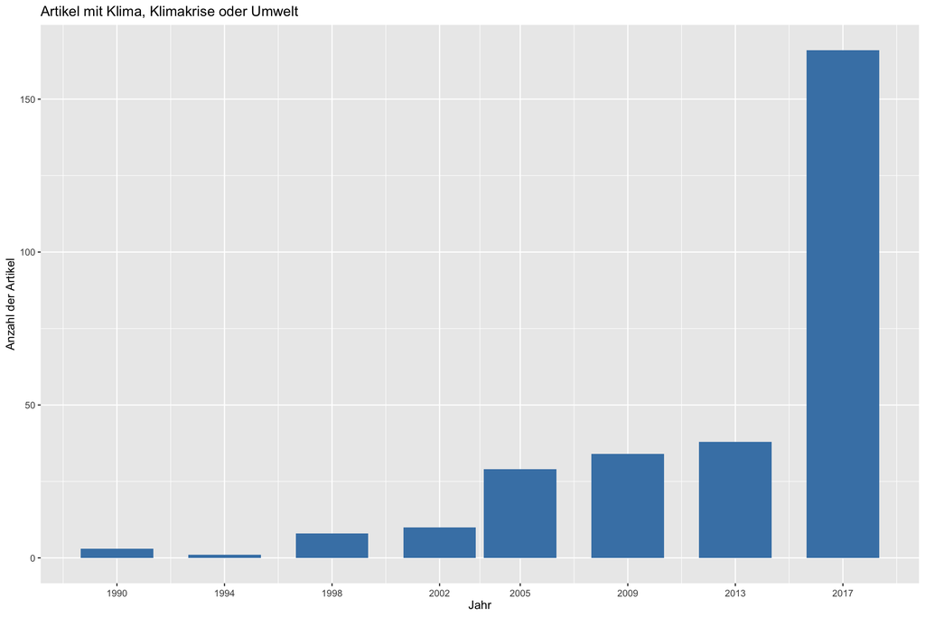

```r
result_match_klima_count <- count(result_match_klima$year)

ggplot(result_match_klima_count, aes(x=x, y=freq)) +
  labs(y = "Anzahl der Artikel", title = "Artikel mit Klima, Klimakrise oder Umwelt") +
  geom_bar(stat = "identity", fill="steelblue")+
  theme(axis.text.x = element_text(vjust = 0.5)) +
  scale_x_continuous("Jahr", breaks = result_match_klima_count$x,
                     labels = as.character(result_match_klima_count$x))
```

### 1.5.2 Visualisierung der Daten zum Thema ‘CDU’ mit R

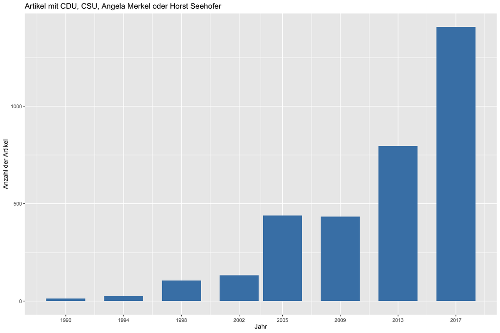

```r
result_match_cdu_csu_year_count <- count(result_match_cdu_csu$year)

ggplot(result_match_cdu_csu_year_count, aes(x=x, y=freq)) +
  labs(y = "Anzahl der Artikel", title = "Artikel mit CDU, CSU, Angela Merkel oder Horst Seehofer") +
  geom_bar(stat = "identity", fill="steelblue")+
  theme(axis.text.x = element_text(vjust = 0.5)) +
  scale_x_continuous("Jahr", breaks = result_match_cdu_csu_year_count$x,
                     labels = as.character(result_match_cdu_csu_year_count$x))
```

### 1.5.3 Wordcloud über die Top10 Publikationen nach Anzahl der Artikel mit Kibana

Die Größe der Verlage repräsentiert die Anzahl der Artikel.

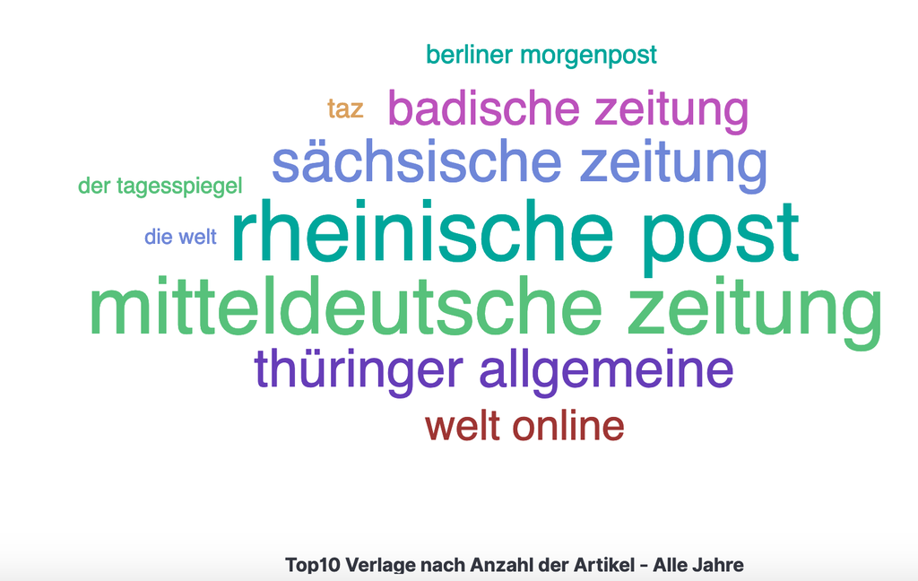

Wordcloud über die Top10 Publikationen nach Anzahl der Artikel mit Kibana

### 1.5.4 Barchart über die Anzahl der Artikel aus den vergangenen Wahljahren mit Kibana

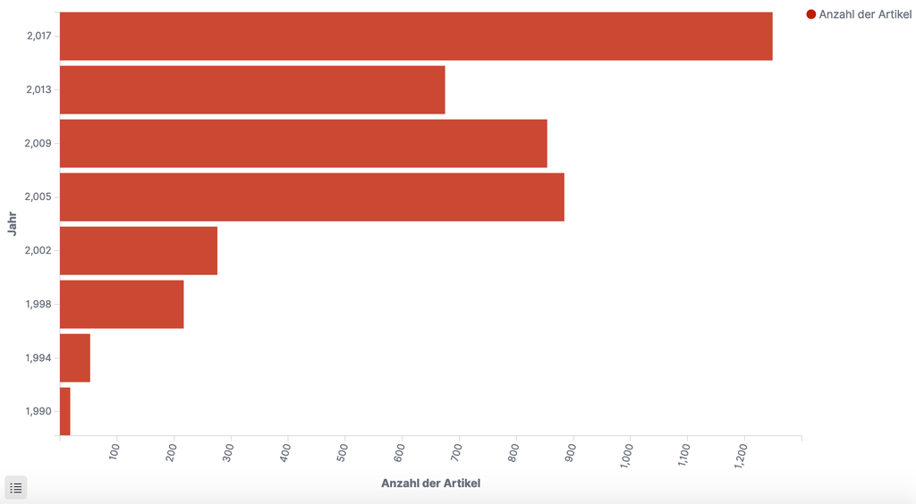

Barchart über die Anzahl der Artikel aus den vergangenen Wahljahren

### 1.5.5 Barchart über die Artikel mit Filtern nach den angegebenen Begriffen mit Kibana

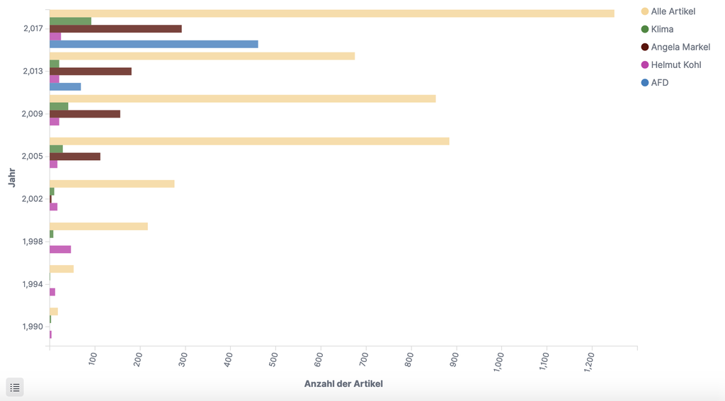

Barchart über die Artikel mit Filtern nach den angegebenen Begriffen

### 1.5.6 Graph über den Begriff AFD mit Kibana

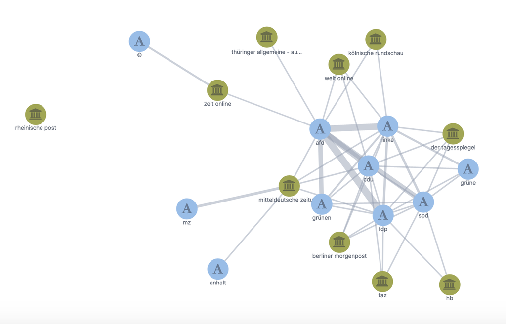

Graph über den Begriff AFD

### 1.5.7 Graph über den Begriff CDU mit Kibana

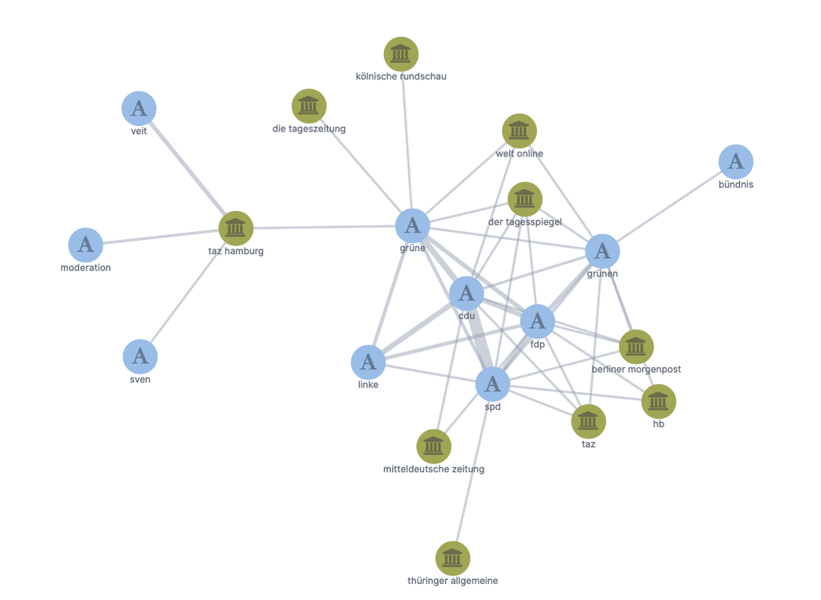

Graph über den Begriff CDU

### 1.5.8 Graph Visualisierung mit den Begriffen “AFD” und “Flüchtlinge” mit Kibana

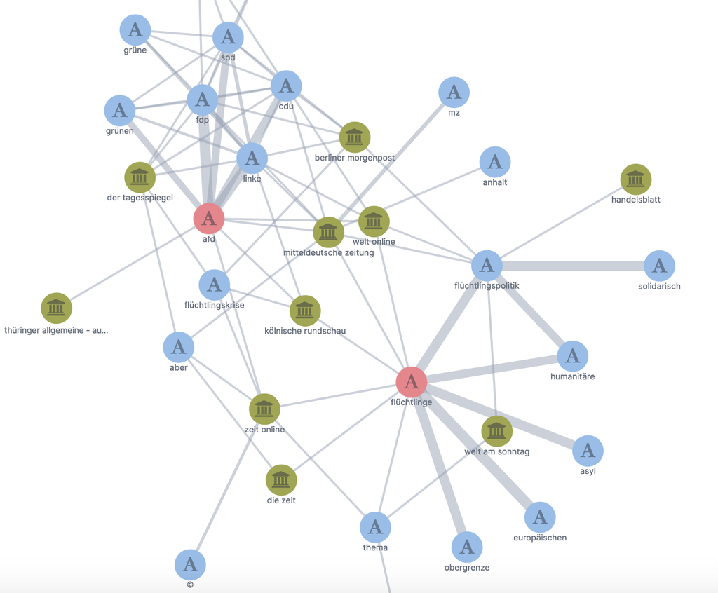

Graph über die Begriffe AFD und Flüchtlinge

## 1.6 13.6. Zugriff auf Kibana-Instanz

Die Kibana-Instanz kann über http://hdm-kibana.think-data.de aufgerufen werden. Die Zugangsdaten können bei den Autoren angefragt werden.